# Project_2

Dillon Hong

3/16/2022

## 0.1 Libraries

```r
library(gmodels)
library(caret)
library(class)
library(neuralnet)
library(kernlab)
library(C50)
```

## 0.2 Data Cleaning and Exploration

```r
hotel <- read.csv("hotel_booking.csv")
hotel$arrival_date_week_number <- as.factor(hotel$arrival_date_week_number)


# Delete Unnecessary Columns

hotel$name <- NULL
hotel$email <- NULL
hotel$phone_number <- NULL
hotel$credit_card <- NULL
hotel$arrival_date_year <- NULL
hotel$arrival_date_week_number <- NULL
hotel$arrival_date_day_of_month <- NULL
hotel$reservation_status_date <- NULL
hotel$reservation_status <- NULL

#hotel$country <- ifelse(is.na(hotel$country), "No Country", na.rm = TRUE), hotel$country)

hotel$country <- NULL

#hotel$agent <- ifelse(is.na(hotel$agent), "No Agent", na.rm = TRUE), hotel$agent)
hotel$agent <- NULL

#hotel$company <- ifelse(is.na(hotel$company), "No Company", na.rm = TRUE), hotel$company)
hotel$company <- NULL


hotel <- subset(hotel, hotel == "City Hotel")
hotel$hotel <- NULL
head(hotel, 200)
```

```
##       is_canceled lead_time arrival_date_month stays_in_weekend_nights
## 40061           0         6               July                       0
## 40062           1        88               July                       0
## 40063           1        65               July                       0
## 40064           1        92               July                       2
## 40065           1       100               July                       0
## 40066           1        79               July                       0
## 40067           0         3               July                       0
## 40068           1        63               July                       1
## 40069           1        62               July                       2
## 40070           1        62               July                       2
## 40071           0        43               July                       0
## 40072           0        43               July                       0
## 40073           0        43               July                       0
## 40074           0         4               July                       0
```

[output cut: 1191 more lines]

### 0.2.1 Check for NAs

```r
cbind(
   lapply(
     lapply(hotel, is.na)
     , sum)
   )
```

```
##                                [,1]
## is_canceled                    0
## lead_time                      0
## arrival_date_month             0
## stays_in_weekend_nights        0
## stays_in_week_nights           0
## adults                         0
## children                       4
## babies                         0
## meal                           0
## market_segment                 0
## distribution_channel           0
## is_repeated_guest              0
## previous_cancellations         0
## previous_bookings_not_canceled 0
## reserved_room_type             0
## assigned_room_type             0
## booking_changes                0
## deposit_type                   0
## days_in_waiting_list           0
## customer_type                  0
## adr                            0
## required_car_parking_spaces    0
## total_of_special_requests      0
```

### 0.2.2 Remove NAs from Children Column

```r
# Checking for NA values in all of the column data
hotel$children <- ifelse(is.na(hotel$children), median(hotel$children, na.rm = TRUE), hotel$children)

cbind(
   lapply(
     lapply(hotel, is.na)
     , sum)
   )
```

```
##                                [,1]
## is_canceled                    0
## lead_time                      0
## arrival_date_month             0
## stays_in_weekend_nights        0
## stays_in_week_nights           0
## adults                         0
## children                       0
## babies                         0
## meal                           0
## market_segment                 0
## distribution_channel           0
## is_repeated_guest              0
## previous_cancellations         0
## previous_bookings_not_canceled 0
## reserved_room_type             0
## assigned_room_type             0
## booking_changes                0
## deposit_type                   0
## days_in_waiting_list           0
## customer_type                  0
## adr                            0
## required_car_parking_spaces    0
## total_of_special_requests      0
```

### 0.2.3 Randomize and Factorize Data

```r
# Randomize the rows in the data (shuffling the rows)
set.seed(12345)
hotel_random <- hotel[sample(nrow(hotel)),]

hotel_random$arrival_date_month <- as.factor(hotel_random$arrival_date_month)
hotel_random$meal <- as.factor(hotel_random$meal)

hotel_random$market_segment <- as.factor(hotel_random$market_segment)
hotel_random$distribution_channel <- as.factor(hotel_random$distribution_channel)
hotel_random$reserved_room_type <- as.factor(hotel_random$reserved_room_type)
hotel_random$assigned_room_type <- as.factor(hotel_random$assigned_room_type)
hotel_random$deposit_type <- as.factor(hotel_random$deposit_type)
hotel_random$customer_type <- as.factor(hotel_random$customer_type)


# Randomize again for good measure
hotel_random <- hotel_random[sample(nrow(hotel_random)),]
```

### 0.2.4 Normalized Data

```r
#get rid of factors so we can use KNN
hotelDummy <- as.data.frame(model.matrix (~ . -1, data = hotel_random))
str(hotelDummy)
```

```
## 'data.frame':    79330 obs. of  61 variables:
##  $ is_canceled                   : num  0 1 0 0 1 0 1 0 0 0 ...
##  $ lead_time                     : num  144 65 0 69 349 30 74 3 6 57 ...
##  $ arrival_date_monthApril       : num  0 0 0 0 0 0 0 0 0 0 ...
##  $ arrival_date_monthAugust      : num  0 0 0 0 0 0 0 0 0 0 ...
##  $ arrival_date_monthDecember    : num  0 0 0 0 0 0 0 0 0 0 ...
##  $ arrival_date_monthFebruary    : num  0 0 0 0 0 0 0 0 0 0 ...
##  $ arrival_date_monthJanuary     : num  0 0 0 0 0 0 0 0 0 0 ...
##  $ arrival_date_monthJuly        : num  0 1 0 0 0 0 0 0 0 0 ...
##  $ arrival_date_monthJune        : num  0 0 1 1 0 0 0 0 0 1 ...
##  $ arrival_date_monthMarch       : num  0 0 0 0 0 1 0 1 0 0 ...
##  $ arrival_date_monthMay         : num  1 0 0 0 0 0 0 0 1 0 ...
##  $ arrival_date_monthNovember    : num  0 0 0 0 0 0 0 0 0 0 ...
##  $ arrival_date_monthOctober     : num  0 0 0 0 1 0 0 0 0 0 ...
##  $ arrival_date_monthSeptember   : num  0 0 0 0 0 0 1 0 0 0 ...
```

[output cut: 47 more lines]

```r
#Normalize the data
normalize <- function(x) {
  return ((x - min(x)) / (max(x) - min(x)))
}

#Normalize entire dataframe
hotel_norm <- as.data.frame(lapply(hotelDummy[2:ncol(hotelDummy)], normalize))
```

### 0.2.5 Test Set

```r
test_set <- sample(1:nrow(hotel_random), 0.2*nrow(hotel_random))
```

```r
#write.csv(hotel_random[test_set, ]$is_canceled, "test_set_values.csv")
```

### 0.2.6 For Knitting Purposes

```r
test_set_is_canceled <- read.csv("test_set_values.csv")
test_set_is_canceled <- test_set_is_canceled$x
```

```r
#write.csv(hotel_random[test_set, ]$is_canceled, "test_set_values.csv")
```

## 0.3 Linear Regression Model

### 0.3.1 Train and Test Dataset

```r
glm_train <- hotel_random[-test_set, ]
glm_test <- hotel_random[test_set, ]

#Now the response (aka Labels) - only the yyes column
glm_train_labels <- hotel_random[-test_set, "is_canceled"]
glm_test_labels <- hotel_random[test_set, "is_canceled"]
```

### 0.3.2 Model

```r
#glm <- glm(is_canceled ~ lead_time + stays_in_week_nights + adr + is_repeated_guest + previous_cancellations +  meal + previous_bookings_not_canceled +   booking_changes + deposit_type + customer_type + total_of_special_requests, data = glm_train, family = 'binomial')
#summary(glm)
```

### 0.3.3 Predictions

```r
#for knitting purposes

##glm_prediction <- as.factor(ifelse(glm_prediction>0.5,1,0))
#write.csv(glm_prediction, "hotel_glm_predictions.csv")
```

### 0.3.4 Matrix

```r
#for knitting purposes
#glm_matrix <- confusionMatrix(glm_prediction, as.factor(glm_test_labels), positive = '1')
glm_prediction <- read.csv("hotel_glm_predictions.csv")
glm_prediction <- glm_prediction$x
glm_matrix <- confusionMatrix(as.factor(glm_prediction), as.factor(test_set_is_canceled), positive = '1')
glm_matrix
```

```
## Confusion Matrix and Statistics
##
##           Reference
## Prediction    0    1
##          0 8693 2880
##          1  440 3853
##
##                Accuracy : 0.7907
##                  95% CI : (0.7843, 0.7971)
##     No Information Rate : 0.5756
##     P-Value [Acc > NIR] : < 2.2e-16
##
##                   Kappa : 0.5503
##
##  Mcnemar's Test P-Value : < 2.2e-16
##
##             Sensitivity : 0.5723
##             Specificity : 0.9518
##          Pos Pred Value : 0.8975
##          Neg Pred Value : 0.7511
##              Prevalence : 0.4244
##          Detection Rate : 0.2428
##    Detection Prevalence : 0.2706
##       Balanced Accuracy : 0.7620
##
##        'Positive' Class : 1
##
```

## 0.4 KNN Model

### 0.4.1 Train and Test Dataset

```r
knn_train <- hotel_norm[-test_set, ]
knn_test <- hotel_norm[test_set, ]

#Now the response (aka Labels) - only the is_canceled column
knn_train_labels <- hotel_random[-test_set, "is_canceled"]
knn_test_labels <- hotel_random[test_set, "is_canceled"]
```

### 0.4.2 Model and Predictions

```r
#knn <- knn(train = knn_train, test = knn_test, cl = knn_train_labels, k=sqrt(length(knn_train_labels)))
#write.csv(knn, "hotel_knn_predictions.csv")
```

### 0.4.3 Confusion Matrix

```r
#for knitting purposes
#knn_matrix <- confusionMatrix(as.factor(knn), as.factor(knn_test_labels))
knn <- read.csv("hotel_knn_predictions.csv")
knn <- knn$x
knn_matrix <- confusionMatrix(as.factor(knn), as.factor(test_set_is_canceled))
knn_matrix
```

```
## Confusion Matrix and Statistics
##
##           Reference
## Prediction    0    1
##          0 8375 2674
##          1  758 4059
##
##                Accuracy : 0.7837
##                  95% CI : (0.7772, 0.7901)
##     No Information Rate : 0.5756
##     P-Value [Acc > NIR] : < 2.2e-16
##
##                   Kappa : 0.54
##
##  Mcnemar's Test P-Value : < 2.2e-16
##
##             Sensitivity : 0.9170
##             Specificity : 0.6029
##          Pos Pred Value : 0.7580
##          Neg Pred Value : 0.8426
##              Prevalence : 0.5756
##          Detection Rate : 0.5279
##    Detection Prevalence : 0.6964
##       Balanced Accuracy : 0.7599
##
##        'Positive' Class : 0
##
```

## 0.5 ANN Model

### 0.5.1 Train and Test Dataset

```r
hotel_norm$is_canceled <- hotel_random$is_canceled

ann_train <- hotel_norm[-test_set, ]
ann_test <- hotel_norm[test_set, ]

#Now the response (aka Labels) - only the yyes column
ann_train_labels <- hotel_norm[-test_set, "is_canceled"]
ann_test_labels <- hotel_norm[test_set, "is_canceled"]
```

### 0.5.2 Model

```r
#ann <- neuralnet(formula = is_canceled ~ .,data = ann_train)
```

### 0.5.3 Prediction

```r
#ann_predictions <- predict(ann, ann_test, type="response")
#ann_predictions <- as.factor(ifelse(ann_predictions>0.5,1,0))

#write.csv(ann_predictions, "hotel_ann_predictions.csv")
```

### 0.5.4 Confusion Matrix

```r
#for knitting purposes
#ann_maxtrix <- confusionMatrix(ann_predictions, as.factor(ann_test_labels))
ann_predictions <- read.csv("hotel_ann_predictions.csv")
ann_predictions <- ann_predictions$x
ann_maxtrix <- confusionMatrix(as.factor(ann_predictions), as.factor(test_set_is_canceled))
ann_maxtrix
```

```
## Confusion Matrix and Statistics
##
##           Reference
## Prediction    0    1
##          0 8379 2191
##          1  754 4542
##
##                Accuracy : 0.8144
##                  95% CI : (0.8082, 0.8204)
##     No Information Rate : 0.5756
##     P-Value [Acc > NIR] : < 2.2e-16
##
##                   Kappa : 0.6091
##
##  Mcnemar's Test P-Value : < 2.2e-16
##
##             Sensitivity : 0.9174
##             Specificity : 0.6746
##          Pos Pred Value : 0.7927
##          Neg Pred Value : 0.8576
##              Prevalence : 0.5756
##          Detection Rate : 0.5281
##    Detection Prevalence : 0.6662
##       Balanced Accuracy : 0.7960
##
##        'Positive' Class : 0
##
```

## 0.6 SVM

### 0.6.1 Train and Test Datasets

```r
svm_train <- hotel_random[-test_set, ]
svm_test <- hotel_random[test_set, ]

svm_train_labels <- hotel_random[-test_set, "is_canceled"]
svm_test_labels <- hotel_random[test_set, "is_canceled"]
```

### 0.6.2 Model - RBF

```r
#svm_rbf <- ksvm(is_canceled ~ ., data = svm_train, kernel = "rbfdot")
```

### 0.6.3 Prediction - RBF

```r
#svm_predictions_rbf <- predict(svm_rbf, svm_test, type= "response")
#svm_predictions_rbf <- as.factor(ifelse(svm_predictions_rbf > 0.5, 1, 0))

#write.csv(svm_predictions_rbf, "hotel_svm_predictions_rbf.csv")
```

### 0.6.4 Confusion Matrix - RBF

```r
#for knitting purposes
#svm_matrix_rbf <- confusionMatrix(svm_predictions_rbf, as.factor(svm_test_labels))
svm_predictions_rbf <- read.csv("hotel_svm_predictions_rbf.csv")
svm_predictions_rbf <- svm_predictions_rbf$x
svm_matrix_rbf <- confusionMatrix(as.factor(svm_predictions_rbf), as.factor(test_set_is_canceled))
svm_matrix_rbf
```

```
## Confusion Matrix and Statistics
##
##           Reference
## Prediction    0    1
##          0 8516 2197
##          1  617 4536
##
##                Accuracy : 0.8226
##                  95% CI : (0.8166, 0.8286)
##     No Information Rate : 0.5756
##     P-Value [Acc > NIR] : < 2.2e-16
##
##                   Kappa : 0.6254
##
##  Mcnemar's Test P-Value : < 2.2e-16
##
##             Sensitivity : 0.9324
##             Specificity : 0.6737
##          Pos Pred Value : 0.7949
##          Neg Pred Value : 0.8803
##              Prevalence : 0.5756
##          Detection Rate : 0.5367
##    Detection Prevalence : 0.6752
##       Balanced Accuracy : 0.8031
##
##        'Positive' Class : 0
##
```

### 0.6.5 Model - Vanilla

```r
## Commented out as the Vanilla Kernel is the less efficient model

#svm_vanilla <- ksvm(is_canceled ~ ., data = svm_train, kernel = "vanilla")
```

### 0.6.6 Prediction - Vanilla

```r
#svm_predictions_vanilla <- predict(svm_vanilla, svm_test, type= "response")
#svm_predictions_vanilla <- as.factor(ifelse(svm_predictions_vanilla > 0.5, 1, 0))

#write.csv(svm_predictions_vanilla, "hotel_svm_predictions_vanilla.csv")
```

### 0.6.7 Confusion Matrix - Vanilla

```r
#svm_matrix_vanilla <- confusionMatrix(svm_predictions_vanilla, as.factor(svm_test_labels))
#svm_matrix_vanilla
```

## 0.7 Decision Tree

### 0.7.1 Train and Test Datasets

```r
tree_train <- hotel_random[-test_set, ]
tree_test <- hotel_random[test_set, ]


prop.table(table(tree_train$is_canceled))
```

```
##
##         0         1
## 0.5845046 0.4154954
```

```r
prop.table(table(tree_test$is_canceled))
```

```
##
##         0         1
## 0.5756334 0.4243666
```

### 0.7.2 Model

```r
#tree <- C5.0(as.factor(is_canceled) ~ ., data = tree_train, trials = 10)
```

### 0.7.3 Prediction

```r
#c50_hotel_pred <- predict(tree, tree_test)
#write.csv(c50_hotel_pred, "hotel_c50_predictions.csv")
```

### 0.7.4 Confusion Matrix

```r
#for knitting purposes
#c50_matrix <- confusionMatrix(c50_hotel_pred, as.factor(tree_test$is_canceled))
c50_hotel_pred <- read.csv("hotel_c50_predictions.csv")
c50_hotel_pred <- c50_hotel_pred$x

c50_matrix <- confusionMatrix(as.factor(c50_hotel_pred), as.factor(test_set_is_canceled))
c50_matrix
```

```
## Confusion Matrix and Statistics
##
##           Reference
## Prediction    0    1
##          0 8331 1501
##          1  802 5232
##
##                Accuracy : 0.8548
##                  95% CI : (0.8493, 0.8603)
##     No Information Rate : 0.5756
##     P-Value [Acc > NIR] : < 2.2e-16
##
##                   Kappa : 0.6988
##
##  Mcnemar's Test P-Value : < 2.2e-16
##
##             Sensitivity : 0.9122
##             Specificity : 0.7771
##          Pos Pred Value : 0.8473
##          Neg Pred Value : 0.8671
##              Prevalence : 0.5756
##          Detection Rate : 0.5251
##    Detection Prevalence : 0.6197
##       Balanced Accuracy : 0.8446
##
##        'Positive' Class : 0
##
```

## 0.8 Stacked Model

```r
glm_predictions <- read.csv("hotel_glm_predictions.csv")
knn_predictions <- read.csv("hotel_knn_predictions.csv")
ann_predictions <- read.csv("hotel_ann_predictions.csv")
svm_predictions <- read.csv("hotel_svm_predictions_rbf.csv")
c50_predictions <- read.csv("hotel_c50_predictions.csv")
actuals <- read.csv('test_set_values.csv')

combo_set <- data.frame(actuals$x, glm_predictions$x, knn_predictions$x, ann_predictions$x, svm_predictions$x, c50_predictions$x)
colnames(combo_set) <- c("Actual", "GLM", "KNN", "ANN", "SVM","TREE")

combo_set$Actual <- as.factor(combo_set$Actual)
```

### 0.8.1 Test and Train

```r
#Set up training data
test_stacked_set <- sample(1:nrow(combo_set), 0.2*nrow(combo_set))

stacked_train <- combo_set[-test_stacked_set,]
stacked_test <- combo_set[test_stacked_set,]
```

### 0.8.2 Model

```r
stacked <- C5.0(as.factor(Actual) ~ ., data = stacked_train, trials = 20)
summary(stacked)
```

```
##
## Call:
## C5.0.formula(formula = as.factor(Actual) ~ ., data = stacked_train, trials = 20)
##
##
## C5.0 [Release 2.07 GPL Edition]      Mon Apr 18 22:42:05 2022
## -------------------------------
##
## Class specified by attribute `outcome'
##
## Read 12693 cases (6 attributes) from undefined.data
##
## -----  Trial 0:  -----
##
## Decision tree:
##
## TREE <= 0: 0 (7831/1202)
## TREE > 0: 1 (4862/640)
##
## -----  Trial 1:  -----
##
## Decision tree:
##
## SVM <= 0: 0 (8756/2916.7)
## SVM > 0: 1 (3937/836.3)
##
## -----  Trial 2:  -----
##
## Decision tree:
##
## GLM > 0: 1 (2877.1/610)
## GLM <= 0:
## :...TREE <= 0: 0 (7520.9/3067.2)
##     TREE > 0: 1 (2295/1050)
##
## -----  Trial 3:  -----
##
## Decision tree:
##
## GLM <= 0: 0 (9898.5/4651.7)
```

[output cut: 22 more lines]

```
##
##     (a)   (b)    <-classified as
##    ----  ----
##    6439   830    (a): class 0
##    1126  4298    (b): class 1
##
##
##  Attribute usage:
##
##  100.00% GLM
##  100.00% SVM
##  100.00% TREE
##
##
## Time: 0.0 secs
```

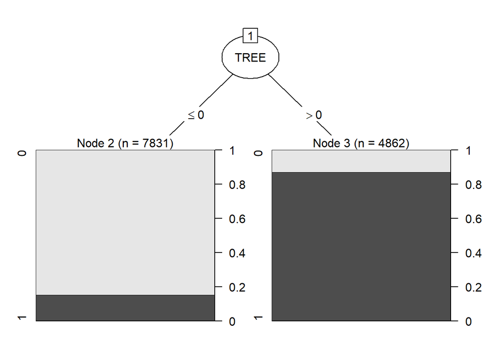

```r
plot(stacked)
```

### 0.8.3 Prediction

```r
stacked_predictions <- predict(stacked, stacked_test)
```

### 0.8.4 Confusion Matrix

```r
stacked_matrix <- confusionMatrix(stacked_predictions, as.factor(stacked_test$Actual))
stacked_matrix
```

```
## Confusion Matrix and Statistics
##
##           Reference
## Prediction    0    1
##          0 1646  280
##          1  218 1029
##
##                Accuracy : 0.8431
##                  95% CI : (0.8299, 0.8555)
##     No Information Rate : 0.5875
##     P-Value [Acc > NIR] : < 2.2e-16
##
##                   Kappa : 0.6739
##
##  Mcnemar's Test P-Value : 0.006267
##
##             Sensitivity : 0.8830
##             Specificity : 0.7861
##          Pos Pred Value : 0.8546
##          Neg Pred Value : 0.8252
##              Prevalence : 0.5875
##          Detection Rate : 0.5188
##    Detection Prevalence : 0.6070
##       Balanced Accuracy : 0.8346
##
##        'Positive' Class : 0
##
```

## 0.9 Conclusion

### 0.9.1 Analysis

```r
hotel <- read.csv("hotel_booking.csv")
hotel <- subset(hotel, hotel == "City Hotel")
hotel$hotel <- NULL
hotel$arrival_date_day_of_month <- as.factor(hotel$arrival_date_day_of_month)
hotel$arrival_date_year <- as.factor(hotel$arrival_date_year)
hotel$arrival_date_month <- as.factor(hotel$arrival_date_month)
hotel$adr <- as.factor(hotel$adr)
hotel$x <- as.double(1)
data <- aggregate(hotel$adr, list(hotel$arrival_date_day_of_month,hotel$arrival_date_year , hotel$arrival_date_month), FUN = function(x) length(unique(x)))
data
```

```
##     Group.1 Group.2   Group.3   x
## 1         1    2016     April  51
## 2         2    2016     April  47
## 3         3    2016     April  39
## 4         4    2016     April  54
## 5         5    2016     April  37
## 6         6    2016     April  48
## 7         7    2016     April  52
## 8         8    2016     April  63
## 9         9    2016     April  47
## 10       10    2016     April  50
## 11       11    2016     April  64
## 12       12    2016     April  54
## 13       13    2016     April  51
## 14       14    2016     April  58
```

[output cut: 779 more lines]

```r
mean(data$x, na.rm = TRUE)
```

```
## [1] 41.51072
```

### 0.9.2 Summary

After sorting through the data to connect how many bookings there are per day, we estimate a daily average of 42 people per day. As a result, that is about 16-17 cancellations per day with an over book of about 16-17 per day with 85% confidence on <1% margin of error. This would be used in the case that the hotel does not have the ability to run the model in order to make predictions. This method has a lot of flaws because it generalizes everyday to be the same when in reality some seasons of the year could have more cancellations than others. If this method were to be used, cancellation can result in loss potential profit that those rooms could have provided. The mean average daily rate (ADR) is $105.30. Therefore, with 16-17 average cancellations that is 16-17 rooms open and opportunity cost of $1,684.80-$1,790.10 per day or $614,952-$653,386.50 per year (assuming 365 days in a year).

For actual usage, the model should be used to directly classify people that are likely to cancel and charge certain rates to those individuals. Some of the others models such as ANN that give a probability instead of a classification could be useful to also classify individuals. Instead of the 0.50 threshold, a higher threshold could be used because some individuals may have higher probability as a result of having more previous cancellations. After classification, a possible solution to counteract this without using overbooking is to charge people classified to cancel a higher rate than ones that aren’t. The charges could be up to double to match the opportunity cost of the room if there is a no show.